# transit cities

Zhanchao Yang, Xian Lu Lee

2025-02-05

## Data prepare

### Data input

```r
FARS <- read.csv("data/mastersheetFARS.csv")
cbsa <- read_excel("data/cbsa_list.xlsx")
```

### Re-create the FIPS code and filter the data

filter to the year 2012-2022 and only include the important code

```r
FARS<-FARS %>%
  filter(YEAR>2011)%>%
  select(YEAR,STATE,COUNTY,fatality_count)
```

FIPS code creation

```r
FARS$FIPS<-sprintf("%02d%03d", FARS$STATE, FARS$COUNTY)
```

## CBSA

cbsa code filtering only include selecting counties cities: NYC, Chicago, Philadelphia, LA, D.C., Boston, Seattle, SF, Baltimore, Pittsburgh cbsa code for 10 cities on the list `msa_codes <- c(35620, 16980, 37980, 31080, 47900, 14460, 42660, 41860, 12580, 38300)`

```r
MSA<- c(35620, 16980, 37980, 31080, 47900, 14460, 42660, 41860, 12580, 38300)
cbsa_10<-cbsa%>%
  filter(`CBSA Code` %in% MSA)%>%
  rename(cbsa_code= `CBSA Code`, cbsa_name= `CBSA Title`)

cbsa_10<- cbsa_10%>%
  select(cbsa_code,cbsa_name,`FIPS State Code`, `FIPS County Code`)%>%
  rename(STATE=`FIPS State Code`, COUNTY=`FIPS County Code`)
```

```r
cbsa_10$COUNTY<-as.numeric(cbsa_10$COUNTY)
cbsa_10$STATE<-as.numeric(cbsa_10$STATE)
cbsa_10$FIPS<-sprintf("%02d%03d", cbsa_10$STATE, cbsa_10$COUNTY)
```

Filtered out FARS Data

```r
FARS<-FARS%>%
  filter(FIPS %in% cbsa_10$FIPS)
```

### Aggregating the FARS by years and county

```r
FARS_final<-FARS%>%
  group_by(YEAR,FIPS)%>%
  summarise(fatality_count=sum(fatality_count))
```

### join the county data into the CBSA

```r
cbsa_10_join <- left_join(cbsa_10, FARS_final, by = "FIPS")
```

aggregate the data to cbsa

```r
cbsa_10_summarize<-cbsa_10_join%>%
  group_by(YEAR,cbsa_code,cbsa_name)%>%
  summarise(fatality_count=sum(fatality_count))
```

```r
cbsa_10_summarize<-cbsa_10_summarize%>%
  filter(!is.na(fatality_count))
```

### write a function to get the ACS by year

```r
get_MSA<- function(year){
  temp <- get_acs(
    geography = "metropolitan statistical area/micropolitan statistical area",
    variables = "B01003_001",
    year = year,
    survey = "acs1"
  ) %>%
    filter(GEOID %in% MSA) %>%
  return(temp)
}
```

### pull the MSA census data by year

```r
MSA_2012<-get_MSA(2012)%>%
  mutate(YEAR=2012)
MSA_2013<-get_MSA(2013)%>%
  mutate(YEAR=2013)
MSA_2014<-get_MSA(2014)%>%
  mutate(YEAR=2014)
MSA_2015<-get_MSA(2015)%>%
  mutate(YEAR=2015)
MSA_2016<-get_MSA(2016)%>%
  mutate(YEAR=2016)
MSA_2017<-get_MSA(2017)%>%
  mutate(YEAR=2017)
MSA_2018<-get_MSA(2018)%>%
  mutate(YEAR=2018)
MSA_2019<-get_MSA(2019)%>%
  mutate(YEAR=2019)
MSA_2021<-get_MSA(2021)%>%
  mutate(YEAR=2021)
MSA_2022<-get_MSA(2022)%>%
  mutate(YEAR=2022)

MSA_ACS<-rbind(MSA_2012,MSA_2013,MSA_2014,MSA_2015,MSA_2016,MSA_2017,MSA_2018,MSA_2019,MSA_2021,MSA_2022)
```

**Note: 2012 LA Metropolitan area is redistrict, so that we cannot get the ACS data directly from ACS, my suggestion is drop 2012 for LA MSA**

### pull up the 2020 census data

```r
MSA_2020<-get_decennial(
  geography = "metropolitan statistical area/micropolitan statistical area",
  variables = "P1_001N",
  year = 2020,
) %>%
  filter(GEOID %in% MSA) %>%
  mutate(YEAR=2020)
```

### join the census and ACS data into the FARS

```r
census_cbsa<- left_join(cbsa_10_summarize, MSA_ACS, by = c("cbsa_code" = "GEOID", "YEAR" = "YEAR")) %>%
  left_join(MSA_2020, by = c("cbsa_code" = "GEOID", "YEAR" = "YEAR"))

census_cbsa<-census_cbsa%>%
  select(YEAR,cbsa_code,cbsa_name,fatality_count,value,estimate)%>%
  mutate(population=ifelse(is.na(value),estimate,value))
```

### calculate the fatality rate

```r
census_cbsa<-census_cbsa%>%
  mutate(fatality_rate=fatality_count/population*100000)
```

### export

```r
write.csv(census_cbsa,"data/MSA_transit_cities_fatality_rate.csv")
```

## Top 10 Transit Cities (Counties level)

### filter to only 10 cities respective counties

New York City, NY (covers multiple counties): - Bronx County: 36005 - Kings County (Brooklyn): 36047 - New York County (Manhattan): 36061 - Queens County: 36081 - Richmond County (Staten Island): 36085

**Question: Should we include the all five counties in the NYC?**

Chicago, IL (Cook County): 17031

Philadelphia, PA (Philadelphia County): 42101

Los Angeles, CA (Los Angeles County): 06037

Washington, D.C. (District of Columbia): 11001

Boston, MA (Suffolk County): 25025

Seattle, WA (King County): 53033

San Francisco, CA (San Francisco County): 06075

Baltimore City (independent): 24510

Pittsburgh, PA (Allegheny County): 42003

```r
county<- c("36005","36047","36061","36081","36085","17031","42101","06037","11001","25025","53033","06075","24510","42003")

FARS_county<-FARS_final%>%
  filter(FIPS %in% county)
```

### Gathering ACS population data

function for ACS

```r
get_county<- function(year){
  temp <- get_acs(
    geography = "county",
    variables = "B01003_001",
    year = year,
    survey = "acs1",
  ) %>%
    filter(GEOID %in% county)%>%
    mutate(YEAR=year)%>%
  return(temp)
}
```

pull out ACS

```r
county_2012<-get_county(2012)
county_2013<-get_county(2013)
county_2014<-get_county(2014)
county_2015<-get_county(2015)
county_2016<-get_county(2016)
county_2017<-get_county(2017)
county_2018<-get_county(2018)
county_2019<-get_county(2019)
county_2021<-get_county(2021)
county_2022<-get_county(2022)
county_sum<-rbind(county_2012,county_2013,county_2014,county_2015,county_2016,county_2017,county_2018,county_2019,county_2021,county_2022)
```

### Gathering Decennial population data

```r
county_2020<-get_decennial(
  geography = "county",
  variables = "P1_001N",
  year = 2020,
) %>%
  filter(GEOID %in% county)%>%
  mutate(YEAR=2020)
```

### join the data with FARS county

```r
census_county<- left_join(FARS_county, county_sum, by = c("FIPS" = "GEOID", "YEAR" = "YEAR")) %>%
  left_join(county_2020, by = c("FIPS" = "GEOID", "YEAR" = "YEAR"))
```

```r
census_county<-census_county%>%
  select(YEAR,FIPS,fatality_count,value,estimate,NAME.x)%>%
  mutate(population=ifelse(is.na(value),estimate,value))%>%
  rename(NAME=NAME.x)
```

```r
census_county<-census_county%>%
  select(YEAR,FIPS,NAME,fatality_count,population)%>%
  mutate(fatality_rate=fatality_count/population*100000)
```

```r
census_county<-census_county%>%
  mutate(county_name=case_when(
    FIPS=="36061"~"New York County,NY",
    FIPS=="17031"~"Cook County,IL",
    FIPS=="42101"~"Philadelphia County,PA",
    FIPS=="06037"~"Los Angeles County,CA",
    FIPS=="11001"~"District of Columbia",
    FIPS=="25025"~"Suffolk County,MA",
    FIPS=="53033"~"King County,WA",
    FIPS=="06075"~"San Francisco County,CA",
    FIPS=="24510"~"Baltimore City,MD",
    FIPS=="42003"~"Allegheny County,PA"
  ))%>%
  filter(!is.na(county_name))
```

### Export the data

```r
census_county %>% select(FIPS,NAME) %>% right_join(census_county %>% select(-NAME),by='FIPS')
```

```
## # A tibble: 1,210 × 8
##    YEAR.x FIPS  NAME  YEAR.y fatality_count population fatality_rate county_name
##     <dbl> <chr> <chr>  <dbl>          <int>      <dbl>         <dbl> <chr>
##  1   2012 06037 Los …   2012            616    9962789          6.18 Los Angele…
##  2   2012 06037 Los …   2013            625   10017068          6.24 Los Angele…
##  3   2012 06037 Los …   2014            639   10116705          6.32 Los Angele…
##  4   2012 06037 Los …   2015            651   10170292          6.40 Los Angele…
##  5   2012 06037 Los …   2016            837   10137915          8.26 Los Angele…
##  6   2012 06037 Los …   2017            751   10163507          7.39 Los Angele…
##  7   2012 06037 Los …   2018            733   10105518          7.25 Los Angele…
##  8   2012 06037 Los …   2019            716   10039107          7.13 Los Angele…
##  9   2012 06037 Los …   2020            760   10014009          7.59 Los Angele…
## 10   2012 06037 Los …   2021            851    9829544          8.66 Los Angele…
## # ℹ 1,200 more rows
```

```r
# write.csv(census_county,"data/county_transit_cities_fatality_rate.csv")
```

## Visualizations

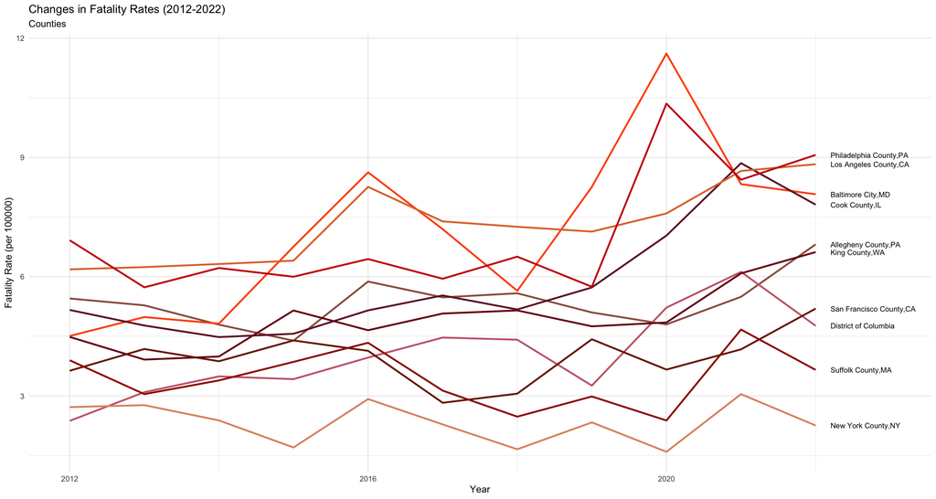

```r
library(ggplot2)
library(ggrepel)
census_county %>% ggplot()+
  geom_line(aes(x=YEAR, y=fatality_rate, color=county_name),lwd=1) +
  scale_color_manual(values = c('#9c5f4f',
'#ff540b',
'#701a31',
'#c9687a',
'#790c1d',
'#e07537',
'#de9670',
'#cb0017',
'#7a2400',
'#9f1700'))+
   geom_text(data = census_county%>% group_by(county_name) %>% filter(YEAR == max(YEAR)),

                  aes(label = county_name, x=YEAR, y=fatality_rate),
                  nudge_x = 0.2, hjust = 0, size=3) +
  xlim(2012,2023)+
  theme_minimal() +
  labs(x = "Year", y = "Fatality Rate (per 100000)", color = "County Name")+
  theme(legend.position = 'hide')+
  ggtitle("Changes in Fatality Rates (2012-2022)", subtitle = 'Counties')
```

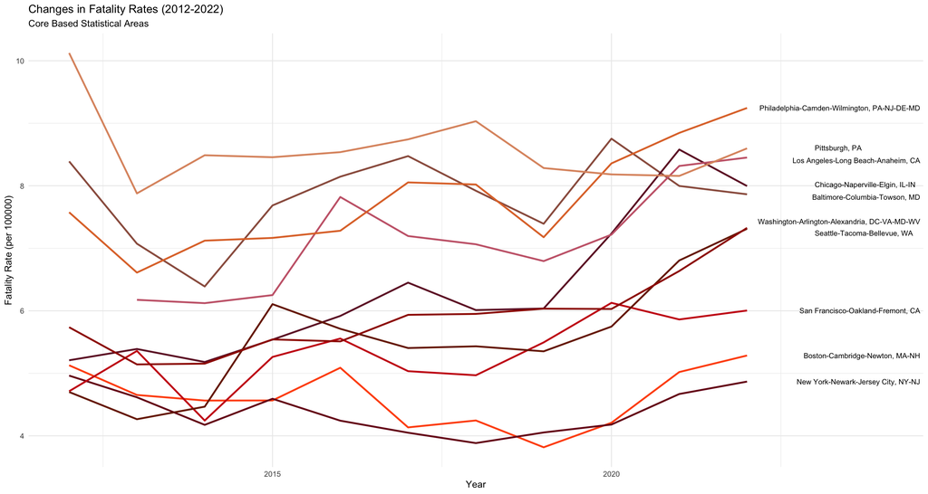

```r
census_cbsa %>% ggplot()+
  geom_line(aes(x=YEAR, y=fatality_rate, color=cbsa_name),lwd=1) +
  scale_color_manual(values = c('#9c5f4f',
'#ff540b',
'#701a31',
'#c9687a',
'#790c1d',
'#e07537',
'#de9670',
'#cb0017',
'#7a2400',
'#9f1700'))+
   geom_text_repel(data = census_cbsa%>% group_by(cbsa_name) %>% filter(YEAR == max(YEAR)),

                  aes(label = cbsa_name, x=YEAR, y=fatality_rate),
                  nudge_x = 1, hjust = 0, size=3, segment.color=NA,direction = "y") +
  xlim(2012,2024)+
  theme_minimal() +
  labs(x = "Year", y = "Fatality Rate (per 100000)", color = "County Name")+
  theme(legend.position = 'hide')+
  ggtitle("Changes in Fatality Rates (2012-2022)", subtitle = 'Core Based Statistical Areas')
```

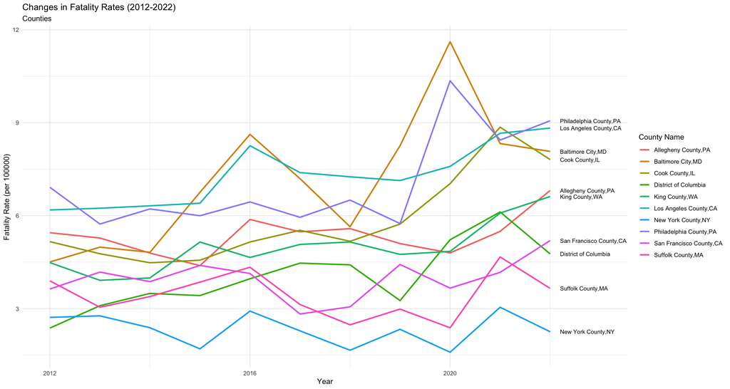

```r
census_county %>% ggplot()+
  geom_line(aes(x=YEAR, y=fatality_rate, color=county_name),lwd=1) +
   geom_text(data = census_county%>% group_by(county_name) %>% filter(YEAR == max(YEAR)),
                  aes(label = county_name, x=YEAR, y=fatality_rate),
                  nudge_x = 0.2, hjust = 0, size=3) +
  xlim(2012,2023)+
  theme_minimal() +
  labs(x = "Year", y = "Fatality Rate (per 100000)", color = "County Name")+
  theme(legend.position = 'right')+
  ggtitle("Changes in Fatality Rates (2012-2022)", subtitle = 'Counties')
```

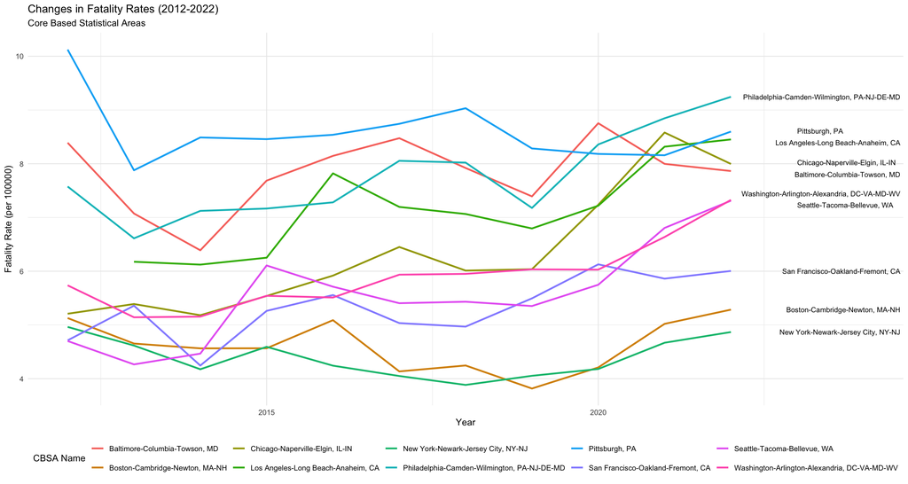

```r
census_cbsa %>% ggplot()+
  geom_line(aes(x=YEAR, y=fatality_rate, color=cbsa_name),lwd=1) +
   geom_text_repel(data = census_cbsa%>% group_by(cbsa_name) %>% filter(YEAR == max(YEAR)),
                  aes(label = cbsa_name, x=YEAR, y=fatality_rate),
                  nudge_x = 1, hjust = 0, size=3, segment.color=NA,direction = "y") +
  xlim(2012,2024)+
  theme_minimal() +
  labs(x = "Year", y = "Fatality Rate (per 100000)", color = "CBSA Name")+
  theme(legend.position = 'bottom')+
  ggtitle("Changes in Fatality Rates (2012-2022)", subtitle = 'Core Based Statistical Areas')
```